# ADSP 32018 - NLP - Assignment 2

### Assignment 2

#### Author: Aashish Singh

Anna - a business executive asked you to improve the accuracy of failed food inspections you produced during Week 1. She advised you to identify specific tokens that lead to failed food inspections in Chicago and produce more accurate list of top-10.

Approach: Use the same data as in assignment 1 but this time identify top-10 tokens that occur in regulation descriptions in the table.

```python
import pandas as pd
import requests
import re
from collections import Counter
import seaborn as sns
import matplotlib.pyplot as plt
from nltk.tokenize import word_tokenize
import nltk
nltk.download('punkt')
nltk.download('stopwords')
from nltk.corpus import stopwords
nltk.download('wordnet')
nltk.download('omw-1.4')
```

```
True
```

```python
import requests

def get_total_count(url):
    try:
        response = requests.get(url)
        response.raise_for_status()  # Check if the request was successful
        if response.text:  # Check if the response is not empty
            return response.json()
        else:
            print("The response is empty.")
            return None
    except requests.exceptions.HTTPError as http_err:
        print(f"HTTP error occurred: {http_err}")
    except requests.exceptions.RequestException as req_err:
        print(f"Request error occurred: {req_err}")
    except requests.exceptions.JSONDecodeError as json_err:
        print(f"JSON decode error occurred: {json_err}")
    return None

# Example usage
url = 'https://data.cityofchicago.org/resource/cwig-ma7x.json'
total_count = get_total_count(url)
print(total_count)
```

[output not shown]

```python
%%time

# Define the API endpoint and parameters
url = "https://data.cityofchicago.org/resource/cwig-ma7x.json"

# Fetch the total count of records
def get_total_count(url):
    params = {
        "$select": "count(*)"
    }
    response = requests.get(url, params=params)
    data = response.json()
    return int(data[0]['count'])

total_count = get_total_count(url)
print(f"Total number of records available: {total_count:,.0f}")
```

```
Total number of records available: 274,206
CPU times: user 19.2 ms, sys: 3.06 ms, total: 22.2 ms
Wall time: 834 ms
```

```python
%%time

# Fetch data and load it into a pandas DataFrame
def fetch_data(url, params):
    response = requests.get(url, params=params)
    data = response.json()
    return pd.DataFrame(data)

# Set the limit parameter equal to the number of available records
params = {
    "$limit": total_count
}

# Fetch the data and load it into a DataFrame
df = fetch_data(url, params)

print(f'Number of records retrieved: {df.shape[0]:,.0f}')
```

```
Number of records retrieved: 274,206
CPU times: user 8.81 s, sys: 1.39 s, total: 10.2 s
Wall time: 33.3 s
```

```python
df.head(5)
```

|  | inspection_id | dba_name | aka_name | license_ | facility_type | risk | address | city | state | zip | ... | results | violations | latitude | longitude | location | :@computed_region_awaf_s7ux | :@computed_region_6mkv_f3dw | :@computed_region_vrxf_vc4k | :@computed_region_bdys_3d7i | :@computed_region_43wa_7qmu |
| --- | --- | --- | --- | --- | --- | --- | --- | --- | --- | --- | --- | --- | --- | --- | --- | --- | --- | --- | --- | --- | --- |
| 0 | 2596677 | NO SAUCE AZ SMOKE HOUSE | NO SAUCE AZ SMOKE HOUSE | 2830744 | Restaurant | Risk 1 (High) | 2055 W 79TH ST | CHICAGO | IL | 60620 | ... | Pass | 37. FOOD PROPERLY LABELED; ORIGINAL CONTAINER ... | 41.75009417468001 | -87.67535799869749 | {'type': 'Point', 'coordinates': [-87.67535799... | 6 | 21554 | 70 | 574 | 30 |
| 1 | 2596644 | SOUTHWEST SENIOR CENTER / GOLDEN DINER | SOUTHWEST SENIOR CENTER / GOLDEN DINER | 2224822 | Golden Diner | Risk 1 (High) | 6117 S KEDZIE AVE | CHICAGO | IL | 60629 | ... | Pass | 51. PLUMBING INSTALLED; PROPER BACKFLOW DEVICE... | 41.782098140853165 | -87.70307836593555 | {'type': 'Point', 'coordinates': [-87.70307836... | 44 | 21867 | 64 | 183 | 2 |
| 2 | 2596657 | LUSHA PIZZA | LUSHA PIZZA | 2971964 | Restaurant | Risk 2 (Medium) | 2825 N LINCOLN AVE | CHICAGO | IL | 60657 | ... | Pass | 53. TOILET FACILITIES: PROPERLY CONSTRUCTED, S... | 41.93321847508229 | -87.65942136953332 | {'type': 'Point', 'coordinates': [-87.65942136... | 16 | 4449 | 57 | 679 | 40 |
| 3 | 2596625 | FOOD FIRST CHICAGO | FOOD FIRST CHICAGO | 2762429 | Catering | Risk 1 (High) | 741 S WESTERN AVE | CHICAGO | IL | 60612 | ... | Pass | 38. INSECTS, RODENTS, & ANIMALS NOT PRESENT - ... | 41.871853705220325 | -87.68603684594997 | {'type': 'Point', 'coordinates': [-87.68603684... | 48 | 21184 | 29 | 757 | 23 |
| 4 | 2596674 | IVY HOTEL | IVY HOTEL | 2653273 | Restaurant | Risk 1 (High) | 233 E ONTARIO ST | CHICAGO | IL | 60611 | ... | Pass | 51. PLUMBING INSTALLED; PROPER BACKFLOW DEVICE... | 41.8932651489868 | -87.62181212015325 | {'type': 'Point', 'coordinates': [-87.62181212... | 22 | 21182 | 37 | 159 | 36 |

5 rows × 22 columns

```python
df.shape
```

```
(274206, 22)
```

#### 1. Similar to Assignment 1, filter the data for failed inspections and only keep records where Violations description is not blank.

```python
failed_inspections = df[(df['results'] == 'Fail') & (df['violations'].notna())]
failed_inspections.shape
```

```
(50134, 22)
```

```python
failed_inspections.head()
```

|  | inspection_id | dba_name | aka_name | license_ | facility_type | risk | address | city | state | zip | ... | results | violations | latitude | longitude | location | :@computed_region_awaf_s7ux | :@computed_region_6mkv_f3dw | :@computed_region_vrxf_vc4k | :@computed_region_bdys_3d7i | :@computed_region_43wa_7qmu |
| --- | --- | --- | --- | --- | --- | --- | --- | --- | --- | --- | --- | --- | --- | --- | --- | --- | --- | --- | --- | --- | --- |
| 17 | 2596661 | HUMBLE EATS | CAFE 75 | 2868591 | Restaurant | Risk 1 (High) | 7550 S HALSTED ST | CHICAGO | IL | 60620 | ... | Fail | 36. THERMOMETERS PROVIDED & ACCURATE - Comment... | 41.756374307698145 | -87.64433680875788 | {'type': 'Point', 'coordinates': [-87.64433680... | 17 | 21554 | 70 | 572 | 31 |
| 21 | 2596651 | GREEN STREET LOCAL | GREEN STREET LOCAL | 2428384 | Restaurant | Risk 1 (High) | 130 S GREEN ST | CHICAGO | IL | 60607 | ... | Fail | 2. CITY OF CHICAGO FOOD SERVICE SANITATION CER... | 41.87950076686327 | -87.64860811802541 | {'type': 'Point', 'coordinates': [-87.64860811... | 41 | 14917 | 29 | 91 | 46 |
| 27 | 2596573 | SOMETHIN SWEET | SOMETHIN SWEET | 2600397 | Restaurant | Risk 2 (Medium) | 4456 N KEDZIE AVE | CHICAGO | IL | 60625 | ... | Fail | 16. FOOD-CONTACT SURFACES: CLEANED & SANITIZED... | 41.962900807070056 | -87.7084444535796 | {'type': 'Point', 'coordinates': [-87.70844445... | 2 | 21849 | 14 | 24 | 20 |
| 32 | 2596534 | KEEPER'S KIDS | KEEPER'S KIDS | 2307735 | Daycare Above and Under 2 Years | Risk 1 (High) | 2718-2724 W 59TH ST | CHICAGO | IL | 60629 | ... | Fail | 1. PERSON IN CHARGE PRESENT, DEMONSTRATES KNOW... | 41.78654294207006 | -87.69204396187506 | {'type': 'Point', 'coordinates': [-87.69204396... | 19 | 21867 | 61 | 112 | 2 |
| 33 | 2596539 | SYMPHONY OF CHICAGO WEST | SYMPHONY JACKSON SQUARE | 2447173 | Long Term Care | Risk 1 (High) | 5130 W JACKSON BLVD | CHICAGO | IL | 60644 | ... | Fail | 16. FOOD-CONTACT SURFACES: CLEANED & SANITIZED... | 41.87677135996502 | -87.75477136468453 | {'type': 'Point', 'coordinates': [-87.75477136... | 11 | 22216 | 26 | 184 | 23 |

5 rows × 22 columns

#### 2. Using regex, separate the violation description and comments into separate data frame columns.

```python
# Let's define a function that select only description and no code / comment
def extract_descriptions(text):
    matches = re.findall(r'\d+\.\s*([^|-]+)', text)
    # Saw that we were getting MUST PROVIDE incorrectly. Modified below to remove those.
    cleaned_matches = [re.split(r'\s-\sComments:|MUST PROVIDE', match)[0].strip() for match in matches]
    # Remove any blanks / empty values
    cleaned_matches = list(filter(None, cleaned_matches))
    return cleaned_matches

# Let's define a function that select only comments and no description
def extract_comments(text):
    # Find all matches for the pattern where comments follow " - Comments:"
    matches = re.findall(r'\d+\.\s*[^\|-]+\s-\sComments:([^|]+)', text)
    # Clean the matches to remove extra spaces and ensure no empty values
    cleaned_matches = [match.strip() for match in matches]
    # Remove any blanks / empty values
    cleaned_matches = list(filter(None, cleaned_matches))
    return cleaned_matches

failed_inspections['violation_descriptions'] = failed_inspections['violations'].apply(extract_descriptions)
failed_inspections['violation_comments'] = failed_inspections['violations'].apply(extract_comments)

# Check if dataframe comes up correctly
print("violation_descriptions has following values for 1 data row:")
print(failed_inspections['violation_descriptions'].apply(tuple).unique()[2])
print("")
print("violation_comments has following values for 1 data row:")
print(failed_inspections['violation_comments'].apply(tuple).unique()[2])
```

```
violation_descriptions has following values for 1 data row:
('FOOD', 'CONTAMINATION PREVENTED DURING FOOD PREPARATION, STORAGE & DISPLAY', 'IN', 'FOOD & NON', 'SEWAGE & WASTE WATER PROPERLY DISPOSED')

violation_comments has following values for 1 data row:
('SPLASH GUARD IS NEEDED BETWEEN SERVING COUNTER TOP AND STORED CLEAN UTENSILS AND HANDWASHING SINK , AT THE FRONT AREA. SURFACE MUST BE SMOOTH,CLEANABLE AND NON-ABSORBENT SURFACE.', 'OBSERVED NO GREASE TRAP INSTALLED ON PREMISES NOR UNDER THREE COMPARTMENT SINK.INSTRUCTED TO INSTALL GRASE TRAP OR T…
```

```python
failed_inspections.head()
```

|  | inspection_id | dba_name | aka_name | license_ | facility_type | risk | address | city | state | zip | ... | latitude | longitude | location | :@computed_region_awaf_s7ux | :@computed_region_6mkv_f3dw | :@computed_region_vrxf_vc4k | :@computed_region_bdys_3d7i | :@computed_region_43wa_7qmu | violation_descriptions | violation_comments |
| --- | --- | --- | --- | --- | --- | --- | --- | --- | --- | --- | --- | --- | --- | --- | --- | --- | --- | --- | --- | --- | --- |
| 17 | 2596661 | HUMBLE EATS | CAFE 75 | 2868591 | Restaurant | Risk 1 (High) | 7550 S HALSTED ST | CHICAGO | IL | 60620 | ... | 41.756374307698145 | -87.64433680875788 | {'type': 'Point', 'coordinates': [-87.64433680... | 17 | 21554 | 70 | 572 | 31 | [THERMOMETERS PROVIDED & ACCURATE, FOOD PROPER... | [OBSERVED NO PROBE THERMOMETER FOR TAKING INTE... |
| 21 | 2596651 | GREEN STREET LOCAL | GREEN STREET LOCAL | 2428384 | Restaurant | Risk 1 (High) | 130 S GREEN ST | CHICAGO | IL | 60607 | ... | 41.87950076686327 | -87.64860811802541 | {'type': 'Point', 'coordinates': [-87.64860811... | 41 | 14917 | 29 | 91 | 46 | [CITY OF CHICAGO FOOD SERVICE SANITATION CERTI... | [NOTED PERSON IN CHARGE WITHOUT ORIGINAL CITY ... |
| 27 | 2596573 | SOMETHIN SWEET | SOMETHIN SWEET | 2600397 | Restaurant | Risk 2 (Medium) | 4456 N KEDZIE AVE | CHICAGO | IL | 60625 | ... | 41.962900807070056 | -87.7084444535796 | {'type': 'Point', 'coordinates': [-87.70844445... | 2 | 21849 | 14 | 24 | 20 | [FOOD, CONTAMINATION PREVENTED DURING FOOD PRE... | [SPLASH GUARD IS NEEDED BETWEEN SERVING COUNTE... |
| 32 | 2596534 | KEEPER'S KIDS | KEEPER'S KIDS | 2307735 | Daycare Above and Under 2 Years | Risk 1 (High) | 2718-2724 W 59TH ST | CHICAGO | IL | 60629 | ... | 41.78654294207006 | -87.69204396187506 | {'type': 'Point', 'coordinates': [-87.69204396... | 19 | 21867 | 61 | 112 | 2 | [PERSON IN CHARGE PRESENT, DEMONSTRATES KNOWLE... | [PIC WITHOUT VALID CITY OF CHICAGO SANITATION ... |
| 33 | 2596539 | SYMPHONY OF CHICAGO WEST | SYMPHONY JACKSON SQUARE | 2447173 | Long Term Care | Risk 1 (High) | 5130 W JACKSON BLVD | CHICAGO | IL | 60644 | ... | 41.87677135996502 | -87.75477136468453 | {'type': 'Point', 'coordinates': [-87.75477136... | 11 | 22216 | 26 | 184 | 23 | [FOOD, CITATION ISSUED., INSECTS, RODENTS, & A... | [OBSERVED APPROXIMATELY 35 SMALL AND LARGE LIV... |

5 rows × 24 columns

#### 3. Tokenize violation description and comment columns

```python
failed_inspections['tokens_descriptions'] = failed_inspections['violation_descriptions'].astype(str).apply(word_tokenize)
failed_inspections['tokens_comments'] = failed_inspections['violation_comments'].astype(str).apply(word_tokenize)
failed_inspections.head()
```

|  | inspection_id | dba_name | aka_name | license_ | facility_type | risk | address | city | state | zip | ... | location | :@computed_region_awaf_s7ux | :@computed_region_6mkv_f3dw | :@computed_region_vrxf_vc4k | :@computed_region_bdys_3d7i | :@computed_region_43wa_7qmu | violation_descriptions | violation_comments | tokens_descriptions | tokens_comments |
| --- | --- | --- | --- | --- | --- | --- | --- | --- | --- | --- | --- | --- | --- | --- | --- | --- | --- | --- | --- | --- | --- |
| 17 | 2596661 | HUMBLE EATS | CAFE 75 | 2868591 | Restaurant | Risk 1 (High) | 7550 S HALSTED ST | CHICAGO | IL | 60620 | ... | {'type': 'Point', 'coordinates': [-87.64433680... | 17 | 21554 | 70 | 572 | 31 | [THERMOMETERS PROVIDED & ACCURATE, FOOD PROPER... | [OBSERVED NO PROBE THERMOMETER FOR TAKING INTE... | [[, 'THERMOMETERS, PROVIDED, &, ACCURATE, ', ,... | [[, 'OBSERVED, NO, PROBE, THERMOMETER, FOR, TA... |
| 21 | 2596651 | GREEN STREET LOCAL | GREEN STREET LOCAL | 2428384 | Restaurant | Risk 1 (High) | 130 S GREEN ST | CHICAGO | IL | 60607 | ... | {'type': 'Point', 'coordinates': [-87.64860811... | 41 | 14917 | 29 | 91 | 46 | [CITY OF CHICAGO FOOD SERVICE SANITATION CERTI... | [NOTED PERSON IN CHARGE WITHOUT ORIGINAL CITY ... | [[, 'CITY, OF, CHICAGO, FOOD, SERVICE, SANITAT... | [[, 'NOTED, PERSON, IN, CHARGE, WITHOUT, ORIGI... |
| 27 | 2596573 | SOMETHIN SWEET | SOMETHIN SWEET | 2600397 | Restaurant | Risk 2 (Medium) | 4456 N KEDZIE AVE | CHICAGO | IL | 60625 | ... | {'type': 'Point', 'coordinates': [-87.70844445... | 2 | 21849 | 14 | 24 | 20 | [FOOD, CONTAMINATION PREVENTED DURING FOOD PRE... | [SPLASH GUARD IS NEEDED BETWEEN SERVING COUNTE... | [[, 'FOOD, ', ,, 'CONTAMINATION, PREVENTED, DU... | [[, 'SPLASH, GUARD, IS, NEEDED, BETWEEN, SERVI... |
| 32 | 2596534 | KEEPER'S KIDS | KEEPER'S KIDS | 2307735 | Daycare Above and Under 2 Years | Risk 1 (High) | 2718-2724 W 59TH ST | CHICAGO | IL | 60629 | ... | {'type': 'Point', 'coordinates': [-87.69204396... | 19 | 21867 | 61 | 112 | 2 | [PERSON IN CHARGE PRESENT, DEMONSTRATES KNOWLE... | [PIC WITHOUT VALID CITY OF CHICAGO SANITATION ... | [[, 'PERSON, IN, CHARGE, PRESENT, ,, DEMONSTRA... | [[, 'PIC, WITHOUT, VALID, CITY, OF, CHICAGO, S... |
| 33 | 2596539 | SYMPHONY OF CHICAGO WEST | SYMPHONY JACKSON SQUARE | 2447173 | Long Term Care | Risk 1 (High) | 5130 W JACKSON BLVD | CHICAGO | IL | 60644 | ... | {'type': 'Point', 'coordinates': [-87.75477136... | 11 | 22216 | 26 | 184 | 23 | [FOOD, CITATION ISSUED., INSECTS, RODENTS, & A... | [OBSERVED APPROXIMATELY 35 SMALL AND LARGE LIV... | [[, 'FOOD, ', ,, 'CITATION, ISSUED, ., ', ,, '... | [[, 'OBSERVED, APPROXIMATELY, 35, SMALL, AND, ... |

5 rows × 26 columns

#### 4. Find top-10 tokens of each column

```python
# Let's find the top 10 tokens for each column
def get_top_tokens(tokens_series, top_n=10):
    all_tokens = [token for tokens in tokens_series for token in tokens]
    token_counts = Counter(all_tokens)
    return token_counts.most_common(top_n)

top_tokens_descriptions = get_top_tokens(failed_inspections['tokens_descriptions'])
top_tokens_comments = get_top_tokens(failed_inspections['tokens_comments'])

print("Top-10 tokens in descriptions:", top_tokens_descriptions)
print("\nTop-10 tokens in comments:", top_tokens_comments)
```

```
Top-10 tokens in descriptions: [(',', 692586), ("'", 400282), ('AND', 190314), (':', 128753), ('.', 80008), ('MAINTAINED', 77010), ('&', 75338), ('INSTALLED', 71910), ("'FOOD", 59743), ('OF', 55056)]

Top-10 tokens in comments: [('.', 545912), (',', 391881), ('AND', 246282), ("'", 232763), ('THE', 190514), ('TO', 186842), ('IN', 157243), ('OF', 117688), ('ON', 115162), ('AT', 112124)]
```

#### 5. Clean each column: convert to lower case, remove stopwords, punctuation, numbers, etc

```python
# Let's define a function that converts columns to lower case, removed stopwords, punctuation, and numbers
def clean_tokens(tokens):
    stop_words = set(stopwords.words('english'))
    cleaned_tokens = [
        token.lower() for token in tokens
        if token.isalpha() and token.lower() not in stop_words
    ]
    return cleaned_tokens

failed_inspections['cleaned_tokens_descriptions'] = failed_inspections['tokens_descriptions'].apply(clean_tokens)
failed_inspections['cleaned_tokens_comments'] = failed_inspections['tokens_comments'].apply(clean_tokens)
```

```python
failed_inspections.head()
```

|  | inspection_id | dba_name | aka_name | license_ | facility_type | risk | address | city | state | zip | ... | :@computed_region_6mkv_f3dw | :@computed_region_vrxf_vc4k | :@computed_region_bdys_3d7i | :@computed_region_43wa_7qmu | violation_descriptions | violation_comments | tokens_descriptions | tokens_comments | cleaned_tokens_descriptions | cleaned_tokens_comments |
| --- | --- | --- | --- | --- | --- | --- | --- | --- | --- | --- | --- | --- | --- | --- | --- | --- | --- | --- | --- | --- | --- |
| 17 | 2596661 | HUMBLE EATS | CAFE 75 | 2868591 | Restaurant | Risk 1 (High) | 7550 S HALSTED ST | CHICAGO | IL | 60620 | ... | 21554 | 70 | 572 | 31 | [THERMOMETERS PROVIDED & ACCURATE, FOOD PROPER... | [OBSERVED NO PROBE THERMOMETER FOR TAKING INTE... | [[, 'THERMOMETERS, PROVIDED, &, ACCURATE, ', ,... | [[, 'OBSERVED, NO, PROBE, THERMOMETER, FOR, TA... | [provided, accurate, properly, labeled, origin... | [probe, thermometer, taking, internal, tempera... |
| 21 | 2596651 | GREEN STREET LOCAL | GREEN STREET LOCAL | 2428384 | Restaurant | Risk 1 (High) | 130 S GREEN ST | CHICAGO | IL | 60607 | ... | 14917 | 29 | 91 | 46 | [CITY OF CHICAGO FOOD SERVICE SANITATION CERTI... | [NOTED PERSON IN CHARGE WITHOUT ORIGINAL CITY ... | [[, 'CITY, OF, CHICAGO, FOOD, SERVICE, SANITAT... | [[, 'NOTED, PERSON, IN, CHARGE, WITHOUT, ORIGI... | [chicago, food, service, sanitation, certifica... | [person, charge, without, original, city, chic... |
| 27 | 2596573 | SOMETHIN SWEET | SOMETHIN SWEET | 2600397 | Restaurant | Risk 2 (Medium) | 4456 N KEDZIE AVE | CHICAGO | IL | 60625 | ... | 21849 | 14 | 24 | 20 | [FOOD, CONTAMINATION PREVENTED DURING FOOD PRE... | [SPLASH GUARD IS NEEDED BETWEEN SERVING COUNTE... | [[, 'FOOD, ', ,, 'CONTAMINATION, PREVENTED, DU... | [[, 'SPLASH, GUARD, IS, NEEDED, BETWEEN, SERVI... | [prevented, food, preparation, storage, displa... | [guard, needed, serving, counter, top, stored,... |
| 32 | 2596534 | KEEPER'S KIDS | KEEPER'S KIDS | 2307735 | Daycare Above and Under 2 Years | Risk 1 (High) | 2718-2724 W 59TH ST | CHICAGO | IL | 60629 | ... | 21867 | 61 | 112 | 2 | [PERSON IN CHARGE PRESENT, DEMONSTRATES KNOWLE... | [PIC WITHOUT VALID CITY OF CHICAGO SANITATION ... | [[, 'PERSON, IN, CHARGE, PRESENT, ,, DEMONSTRA... | [[, 'PIC, WITHOUT, VALID, CITY, OF, CHICAGO, S... | [charge, present, demonstrates, knowledge, per... | [without, valid, city, chicago, sanitation, ce... |
| 33 | 2596539 | SYMPHONY OF CHICAGO WEST | SYMPHONY JACKSON SQUARE | 2447173 | Long Term Care | Risk 1 (High) | 5130 W JACKSON BLVD | CHICAGO | IL | 60644 | ... | 22216 | 26 | 184 | 23 | [FOOD, CITATION ISSUED., INSECTS, RODENTS, & A... | [OBSERVED APPROXIMATELY 35 SMALL AND LARGE LIV... | [[, 'FOOD, ', ,, 'CITATION, ISSUED, ., ', ,, '... | [[, 'OBSERVED, APPROXIMATELY, 35, SMALL, AND, ... | [issued, rodents, animals, present, rodents, a... | [approximately, small, large, live, flies, fly... |

5 rows × 28 columns

#### 6. Find top-10 tokens again

```python
# Let's find the top 10 tokens for each column
def get_top_tokens(tokens_series, top_n=10):
    all_tokens = [token for tokens in tokens_series for token in tokens]
    token_counts = Counter(all_tokens)
    return token_counts.most_common(top_n)

top_cleaned_tokens_descriptions = get_top_tokens(failed_inspections['cleaned_tokens_descriptions'])
top_cleaned_tokens_comments = get_top_tokens(failed_inspections['cleaned_tokens_comments'])

print("Top-10 tokens in cleaned_token_descriptions:", top_cleaned_tokens_descriptions)
print("\nTop-10 tokens in cleaned_token_comments:", top_cleaned_tokens_comments)
```

```
Top-10 tokens in cleaned_token_descriptions: [('maintained', 77067), ('installed', 71920), ('clean', 52912), ('equipment', 50972), ('properly', 49895), ('food', 48280), ('constructed', 45233), ('repair', 41269), ('non', 40999), ('good', 38709)]

Top-10 tokens in cleaned_token_comments: [('instructed', 102638), ('food', 96465), ('must', 87282), ('area', 69249), ('sink', 67444), ('provide', 65434), ('violation', 61936), ('maintain', 58506), ('priority', 57314), ('issued', 54333)]
```

#### 7. Find top-10 tokens after applying Porter stemming to the columns obtained in step 5.

```python
%%time
from nltk.stem import PorterStemmer

def porter_stem_tokens(tokens):
    porter = PorterStemmer()
    porter_stemmed_tokens = [porter.stem(token) for token in tokens]
    return porter_stemmed_tokens

failed_inspections['porter_tokens_descriptions'] = failed_inspections['cleaned_tokens_descriptions'].apply(porter_stem_tokens)
failed_inspections['porter_tokens_comments'] = failed_inspections['cleaned_tokens_comments'].apply(porter_stem_tokens)

# Let's find the top 10 tokens for each column
def get_top_tokens(tokens_series, top_n=10):
    all_tokens = [token for tokens in tokens_series for token in tokens]
    token_counts = Counter(all_tokens)
    return token_counts.most_common(top_n)

top_porter_tokens_descriptions = get_top_tokens(failed_inspections['porter_tokens_descriptions'])
top_porter_tokens_comments = get_top_tokens(failed_inspections['porter_tokens_comments'])

print("Top-10 tokens in porter_tokens_descriptions:", top_porter_tokens_descriptions)
print("\nTop-10 tokens in porter_tokens_comments:", top_porter_tokens_comments)
```

[output not shown]

```
Top-10 tokens in porter_tokens_descriptions: [('maintain', 88951), ('clean', 88939), ('instal', 72649), ('food', 58096), ('equip', 51072), ('properli', 49895), ('construct', 45255), ('repair', 42100), ('non', 40999), ('facil', 39488)]

Top-10 tokens in porter_tokens_comments: [('food', 121538), ('instruct', 102786), ('area', 96009), ('must', 87284), ('sink', 81685), ('provid', 76067), ('maintain', 68012), ('violat', 65316), ('prioriti', 57314), ('issu', 55178)]
CPU times: user 2min 6s, sys: 827 ms, total: 2min 7s
Wall time: 2min 10s
```

#### 8. Find top-10 tokens after applying Lancaster stemming to the columns obtained in step 5.

```python
%%time
from nltk.stem import LancasterStemmer

def lancaster_stem_tokens(tokens):
    lancaster = LancasterStemmer()
    lancaster_stemmed_tokens = [lancaster.stem(token) for token in tokens]
    return lancaster_stemmed_tokens

failed_inspections['lancaster_tokens_descriptions'] = failed_inspections['cleaned_tokens_descriptions'].apply(lancaster_stem_tokens)
failed_inspections['lancaster_tokens_comments'] = failed_inspections['cleaned_tokens_comments'].apply(lancaster_stem_tokens)

# Let's find the top 10 tokens for each column
def get_top_tokens(tokens_series, top_n=10):
    all_tokens = [token for tokens in tokens_series for token in tokens]
    token_counts = Counter(all_tokens)
    return token_counts.most_common(top_n)

top_lancaster_tokens_descriptions = get_top_tokens(failed_inspections['lancaster_tokens_descriptions'])
top_lancaster_tokens_comments = get_top_tokens(failed_inspections['lancaster_tokens_comments'])

print("Top-10 tokens in lancaster_tokens_descriptions:", top_lancaster_tokens_descriptions)
print("\nTop-10 tokens in lancaster_tokens_comments:", top_lancaster_tokens_comments)
```

[output not shown]

```
Top-10 tokens in lancaster_tokens_descriptions: [('cle', 90744), ('maintain', 88951), ('instal', 72649), ('prop', 63530), ('food', 58096), ('equip', 51072), ('construct', 45255), ('repair', 42100), ('non', 41005), ('facil', 39495)]

Top-10 tokens in lancaster_tokens_comments: [('food', 121539), ('instruct', 102803), ('must', 87284), ('sink', 81685), ('provid', 76684), ('are', 69249), ('maintain', 68019), ('viol', 65329), ('stor', 64564), ('prep', 61902)]
CPU times: user 1min 37s, sys: 2.03 s, total: 1min 39s
Wall time: 1min 41s
```

#### 9. Find top-10 tokens after applying lemmatization to the columns obtained in step 5.

```python
%%time
from nltk.stem import WordNetLemmatizer

def lemmatize_tokens(tokens):
    lemmatizer = WordNetLemmatizer()
    lemmatized_tokens = [lemmatizer.lemmatize(token) for token in tokens]
    return lemmatized_tokens

failed_inspections['lemmatized_tokens_descriptions'] = failed_inspections['cleaned_tokens_descriptions'].apply(lemmatize_tokens)
failed_inspections['lemmatized_tokens_comments'] = failed_inspections['cleaned_tokens_comments'].apply(lemmatize_tokens)


# Let's find the top 10 tokens for each column
def get_top_tokens(tokens_series, top_n=10):
    all_tokens = [token for tokens in tokens_series for token in tokens]
    token_counts = Counter(all_tokens)
    return token_counts.most_common(top_n)

top_lemmatized_tokens_descriptions = get_top_tokens(failed_inspections['lemmatized_tokens_descriptions'])
top_lemmatized_tokens_comments = get_top_tokens(failed_inspections['lemmatized_tokens_comments'])

print("Top-10 tokens in lemmatized_tokens_descriptions:", top_lemmatized_tokens_descriptions)
print("\nTop-10 tokens in lemmatized_tokens_comments:", top_lemmatized_tokens_comments)
```

[output not shown]

```
Top-10 tokens in lemmatized_tokens_descriptions: [('maintained', 77067), ('installed', 71920), ('food', 58096), ('clean', 52912), ('equipment', 50998), ('properly', 49895), ('constructed', 45233), ('repair', 41295), ('non', 40999), ('facility', 39488)]

Top-10 tokens in lemmatized_tokens_comments: [('food', 121537), ('instructed', 102638), ('area', 96008), ('must', 87283), ('sink', 81685), ('provide', 65434), ('violation', 65311), ('maintain', 58506), ('priority', 57314), ('citation', 54439)]
CPU times: user 23.5 s, sys: 277 ms, total: 23.8 s
Wall time: 24.1 s
```

#### 10. Compare top-10 tokens obtained in 4, 6, 7, 8, 9

Step 4. Top 10 tokens from original columns

Top-10 tokens in descriptions: [(',', 692586), ("'", 400282), ('AND', 190314), (':', 128753), ('.', 80008), ('MAINTAINED', 77010), ('&', 75338), ('INSTALLED', 71910), ("'FOOD", 59743), ('OF', 55056)]

Top-10 tokens in comments: [('.', 545912), (',', 391881), ('AND', 246282), ("'", 232763), ('THE', 190514), ('TO', 186842), ('IN', 157243), ('OF', 117688), ('ON', 115162), ('AT', 112124)]

Step 6. Top 10 tokens from cleaned columns

Top-10 tokens in cleaned_token_descriptions: [('maintained', 77067), ('installed', 71920), ('clean', 52912), ('equipment', 50972), ('properly', 49895), ('food', 48280), ('constructed', 45233), ('repair', 41269), ('non', 40999), ('good', 38709)]

Top-10 tokens in cleaned_token_comments: [('instructed', 102638), ('food', 96465), ('must', 87282), ('area', 69249), ('sink', 67444), ('provide', 65434), ('violation', 61936), ('maintain', 58506), ('priority', 57314), ('issued', 54333)]

Step 7. Top 10 tokens from Porter stemming columns

Top-10 tokens in porter_tokens_descriptions: [('maintain', 88951), ('clean', 88939), ('instal', 72649), ('food', 58096), ('equip', 51072), ('properli', 49895), ('construct', 45255), ('repair', 42100), ('non', 40999), ('facil', 39488)]

Top-10 tokens in porter_tokens_comments: [('food', 121538), ('instruct', 102786), ('area', 96009), ('must', 87284), ('sink', 81685), ('provid', 76067), ('maintain', 68012), ('violat', 65316), ('prioriti', 57314), ('issu', 55178)]

Step 8. Top 10 tokens from Lancaster stemming columns

Top-10 tokens in lancaster_tokens_descriptions: [('cle', 90744), ('maintain', 88951), ('instal', 72649), ('prop', 63530), ('food', 58096), ('equip', 51072), ('construct', 45255), ('repair', 42100), ('non', 41005), ('facil', 39495)]

Top-10 tokens in lancaster_tokens_comments: [('food', 121539), ('instruct', 102803), ('must', 87284), ('sink', 81685), ('provid', 76684), ('are', 69249), ('maintain', 68019), ('viol', 65329), ('stor', 64564), ('prep', 61902)]

Step 9. Top 10 tokens from lemmatization columns

Top-10 tokens in lemmatized_tokens_descriptions: [('maintained', 77067), ('installed', 71920), ('food', 58096), ('clean', 52912), ('equipment', 50998), ('properly', 49895), ('constructed', 45233), ('repair', 41295), ('non', 40999), ('facility', 39488)]

Top-10 tokens in lemmatized_tokens_comments: [('food', 121537), ('instructed', 102638), ('area', 96008), ('must', 87283), ('sink', 81685), ('provide', 65434), ('violation', 65311), ('maintain', 58506), ('priority', 57314), ('citation', 54439)]

#### 11. Describe which approach provided the most comprehensive view of violations / comments and why

Among the approaches used for analyzing the food inspection data, Lemmatization and Porter stemming method provided the best results for comprehensive view of violations and comments. Lancaster stemming method reduced words to very short tokens that were less interpretable (e.g., "properly" to "prop"). Overall, Lemmatization better inpretation wise and does the job here quickly too.

#### 12. Use the "most effective" cleaning approach to plot the distribution of most common tokens (belonging to violation description) over time

```python
top_lemmatized_tokens_descriptions
```

```
[('maintained', 77067),
 ('installed', 71920),
 ('food', 58096),
 ('clean', 52912),
 ('equipment', 50998),
 ('properly', 49895),
 ('constructed', 45233),
 ('repair', 41295),
 ('non', 40999),
 ('facility', 39488)]
```

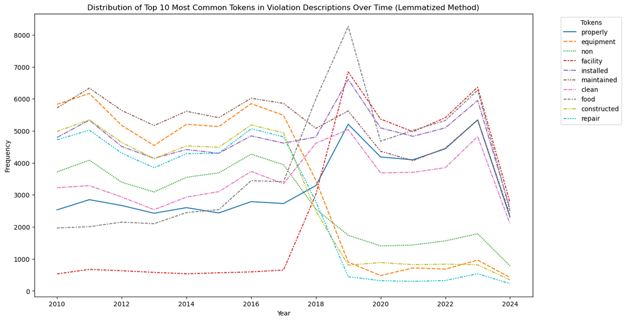

```python
failed_inspections['inspection_year'] = pd.to_datetime(failed_inspections['inspection_date']).dt.year
top_tokens = [token for token, count in top_lemmatized_tokens_descriptions]

# Flatten the list of tokens and get the count by year
def get_token_frequencies_by_year(tokens_series, year_series, top_tokens):
    token_frequencies = {}
    for tokens, year in zip(tokens_series, year_series):
        if year not in token_frequencies:
            token_frequencies[year] = Counter()
        filtered_tokens = [token for token in tokens if token in top_tokens]
        token_frequencies[year].update(filtered_tokens)
    return token_frequencies

token_frequencies_by_year = get_token_frequencies_by_year(
    failed_inspections['lemmatized_tokens_descriptions'],
    failed_inspections['inspection_year'],
    top_tokens)

token_frequencies_df = pd.DataFrame(token_frequencies_by_year).fillna(0).T

# Plot the distribution of the most common tokens over time
plt.figure(figsize=(14, 8))
sns.lineplot(data=token_frequencies_df)
plt.title("Distribution of Top 10 Most Common Tokens in Violation Descriptions Over Time (Lemmatized Method)")
plt.xlabel("Year")
plt.ylabel("Frequency")
plt.legend(title='Tokens', bbox_to_anchor=(1.05, 1), loc='upper left')
plt.show()
```